# Reaksjonsfarten av krystallfiolett

### PROSJEKT 2

LAGET AV: EMMA MEYER LARSSON OG MAY-LINN SKULAND

Oppgaven vi har valgt handler om reaksjonshastigheten av krystallfiolett(CV), som blir avfarget i reaksjon med NaOH. Vi vil ikke fokusere på $Na^+$-ionet ettersom dette bare er et tilskuerion, og dermed ikke relevant.

Reaksjonslikningen vi skal se på er: $CV^+ (aq) + OH^- (aq) ⇄ CVOH (aq) $

### Oppgave 1

En ratelov er produktet av pseudoratekonstanten og konsentrasjonene til reaktantene i reasjonen. En ratelov er forskjellig fra reaksjon til reaksjon, ut fra hvilke stoffer som reagerer med hverandre.

Rateloven er endring av produktet delt på tid.

Ratekoeffisienten bestemmes via Beers lov. Der bruker du observasjoner fra et forsøk til å finne konstanten til rateloven. De andre faktorene bestemmes eksprimentelt, med tilnærmet valgfrie konsentrasjoner.

### Oppgave 2

Første eller andre ordens rate lov bestemmer vi ut i fra eksperimentet, eksperimentelt, og setter enten den ene, den andre, eller begge konsentrasjonene opphøyd i annen. Målet er å lage en modell som passer best mulig med svarene i eksperimentet.

Første ordens:

$v = c’(t) = k_r[CV^+][OH^-]$

Andre ordens:

$v = c’(t) = k_r[CV^+]^2[OH^-]^2$

$[OH^-]$ settes i nullte orden fordi vi i vårt forsøk hadde mye mer $OH^-$ enn $CV^+$. Dette gjør at konsentrasjonen av $OH^-$ er tilnærmet uforandret i forhold til $CV^+$. $[CV^+]$ setter vi i første orden fordi det er det som gir en lineær graf når vi tar logaritmen av $[CV^+]$.

ln($[CV^+]$) = k’t + ln($[CV^+]_0$)

Det gjør at formelen for rateloven vil se slik ut:

Δ[CVOH]/Δt = k'$[CV^+]^1$$[OH^-]^0$

Δ[CVOH]/Δt = k'$[CV^+]^1$

### Oppgave 3

Konsentrasjon: Vi skulle ha en ekstremt liten konsentrasjon av CV i løsningen og det gjorde at vi måtte lage en del og fortynne mange ganger.Første fortynnet vi 0.061 gram CV i 100 mL vann, og tok videre 1 mL av den løsningen for å fortynne den i 100 mL vann. Vi fortynnet den første løsningen 100 ganger. Siden vi skulle ha så liten mengde med CV gjorde dette at det kunne oppstå en del feil ved målingen og lagingen av løsningene.

Kalibereing: Vekten vi brukte var veldig nøyaktig. Siden vi skulle ha en veldig liten konsentrasjon av CV var det viktig å ha en velkt som kunne vise oss nok desimaler.

Temperatur: Vi brukte romtemperert destilert vann. Vi ville unngå for store temperaturendring fordi det kunne spille ut på forsøket. Ved å bruke romtemperert vann er vi sikre på at tempraturen ikke endrer segetter hvert i forsøket.

Kyvette: Vi brukte en ca 1.0 cm bred kyvette. (estimert data:))

### Oppgave 4

Resultatene fra forsøket vi gjorde

```python
#Importerer
import pylab as pl
import pandas as pd

#Leser av filen til forsøket
fil = pl.loadtxt('spektrometridata.csv',float, delimiter=';')

x = fil[:,0]   #tid i sekunder
y = fil[:,1]   #absorbsjon
```

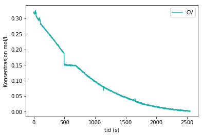

```python
#PLOT

pl.legend('Reaksjon for dannelse av CVOH')
pl.xlabel('tid (s)')
pl.ylabel('Konsentrasjon mol/L')
pl.plot(x,y, label = 'CV', color = 'lightseagreen')
pl.legend(loc=0)
```

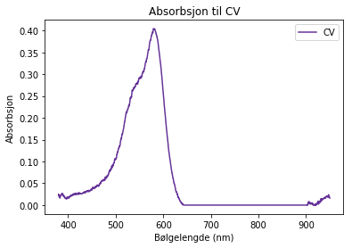

```python
#Leser av filen og plotter absorbsjonen til CV
fil = pl.loadtxt('absorbsjonCV.csv',float, delimiter=';')

Bølgelengde = fil[:,0]   #tid i sekunder
Absorbsjon = fil[:,1]   #absorbsjon

pl.title('Absorbsjon til CV')
pl.legend('Absorbsjon til CV')
pl.xlabel('Bølgelengde (nm)')
pl.ylabel('Absorbsjon')
pl.plot(Bølgelengde,Absorbsjon, label = 'CV', color = 'rebeccapurple')
pl.legend(loc=0)
```

I eksprimentet der vi blander $OH^-$ og $CV^+$ vil det blir dannet CVOH. $CV^+$ har en sterk lilla farge, mens CVOH er blank. Etter hvert som eksprimentet går vil blandingen av $OH^-$ og $CV^+$ gå fra lilla til blank.

Grafen over viser absorsjonen av løsningen med $CV^+$. Absorbsjonen er høyest av lys med bølgelengder mellom 500 nm - 600 nm, som er det vi ser som grønt og gult lys. Det er lite absorbsjon av lys som har bølgelengder mellom 400 nm og 500 nm, som er det vi ser som blått og rødt. Det er derfor løsningen er lilla.

### Oppgave 5

Bestemmer ratekoeffisienten via Beers lov

Beers lov:

## $A = k_s*l*c$

Vi finner $k_s$ ved å sette inn :

- A (absorbsjonen av $CV^+$ ved start)
- l (bredden på kyvetten)
- c (konsentrasjonen av $CV^+$ ved start)

c vet vi allerede er $1.5*10^-5$ M og A finner vi som den første målingen ved forsøket

```python
A = 0.319
l = 1
c = 1.5E-5

k_s = A/(l*c)

print(k_s)
```

```
21266.666666666668
```

Når vi har funnet $k_s$ kan vi regne ut de konsentrasjonene som vi trenger for å finne k'. Med absorbsjonen regner vi ut konsentrasjonene av $[CV^+]$ ved start. Vi regner ut [CVOH] ved stat og [CVOH] ved slutt for å finne Δ[CVOH], ut fra $[CV^+]$ ved start.

```python
A_CV_start = 0.319   #Abrobsjon av CV ved start, funnet eksprimentelt
A_CV_slutt = 0.003
CVOH_start = A_CV_start/(k_s)
CVOH_slutt = A_CV_slutt/(k_s)

delta_CVOH = CVOH_start-CVOH_slutt

k = (delta_CVOH)/(2500*1.41E-7)

print('k = ',k)
```

```
k =  0.042153004735543245
```

k' og k har samme verdi fordi:

$k' = k * [OH^-]^0$

og $[OH^-]^0$ er lik 1

$k' = k * 1$

# $k' = k$

### Oppgave 6

```python
CV_0 = 1.5E-5     #konsentrason av CV ved start
OH_0 = 0.05    #konsentrasjon av OH ved start
CVOH_0 = 0   #konsentrasjon av CVOH ved start


#Tidssteg
N = 100000 #antall intervller
tid = 2500    #tid i minutter
dt = tid/(N-1)

#Matriser
t = pl.zeros(N)
CV = pl.zeros(N)
OH = pl.zeros(N)
CVOH = pl.zeros(N)
CV_der = pl.zeros(N)
OH_der = pl.zeros(N)
CVOH_der = pl.zeros(N)


#Initierer matriser
CV[0] = CV_0
OH[0] = OH_0
CVOH[0] = CVOH_0
```

```python
#Eulers metode
for i in range(N-1):
    CVOH_der[i] = k*CV[i]*OH[i]
    CV_der[i] = - CVOH_der[i]
    OH_der[i] = CV_der[i]
    CV[i+1] = CV[i]+CV_der[i]*dt
    OH[i+1] = OH[i]+OH_der[i]*dt
    CVOH[i+1] = CVOH[i]+CVOH_der[i]*dt
    t[i+1] = t[i] + dt
```

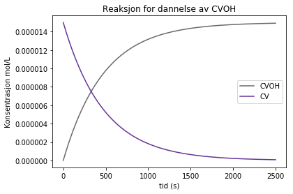

```python
#PLOT
pl.title('Reaksjon for dannelse av CVOH')
pl.legend('Reaksjon for dannelse av CVOH')
pl.xlabel('tid (s)')
pl.ylabel('Konsentrasjon mol/L')
pl.plot(t,CVOH, label = 'CVOH', color = 'dimgrey')
pl.plot(t,CV, label = 'CV', color = 'rebeccapurple')
pl.legend(loc=0)
```

#### Feilkilder

- Avrundingsfeil
- Målefeil fordi vekten ikke var nøyaktige nok, eller vi ikke var nøyaktige nok.
- Ikke all krystallfioletten løste seg opp, og ble dermed ikke med i reaksjonen
- Feil målinger i Pasco Spectrometry programmet pga pcen sluknet
- (mye mer NaOH enn CV+, fordi da vil ikke OH- ionene ha like mye å si for reaksjonen)